# Mini-projet MDI 220 Ruila Puskas-Juhasz

```r
data("discoveries")
```

```
There were 50 or more warnings (use warnings() to see the first 50)
```

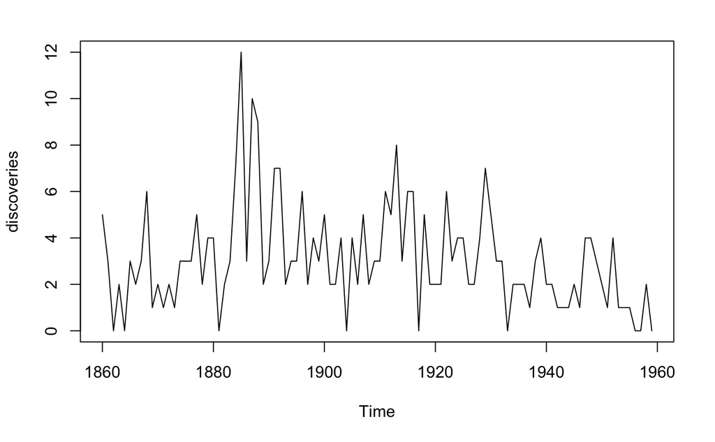

```r
plot(discoveries)
```

## Exercice 1

**2.** Dans le cas d’une loi de Poisson ou le parametre inconnu est $\lambda$, on trouve l’expression de $\hat{\lambda}$ en passant par la log-vraisemblance : $log(p(x, \lambda )) = \sum_{} x_i log( \lambda ) -n\lambda - \sum_{} log(x_i !)$ En annulant la drive par rapport $\lambda$ on obtient : $\frac{1}{\lambda} \sum{} x_i - n = 0$ $\hat{\lambda} = \frac{1}{n} \sum_{i=1}^{n} x_i$

```r
#calcul de la moyenne et de la variance empirique du jeu de donnees
m = mean (discoveries)
v = var (discoveries)
print("moyenne empirique")
```

```
[1] "moyenne empirique"
```

```r
print(m)
```

```
[1] 3.1
```

```r
print("variance empirique")
```

```
[1] "variance empirique"
```

```r
print(v)
```

```
[1] 5.080808
```

```r
#calcul <c3><a0> partir de l'estimateur de la loi g<c3><a9>omtrique
n = length(discoveries)
S = 0
for (i in (1:n)) {
  S <- S + discoveries[i]
}
theta = 1/((1/n)*S +1)
moy_geom = (1/n)*S + 1 ##1/theta
var_geom = (1-theta)/(theta**2)
print ('moyenne geometrique')
```

```
[1] "moyenne geometrique"
```

```r
print(moy_geom)
```

```
[1] 4.1
```

```r
print('variance geometrique')
```

```
[1] "variance geometrique"
```

```r
print(var_geom)
```

```
[1] 12.71
```

```r
#calcul <c3><a0> partir de l'estimateur de la loi de Poisson
lambda = (1/n)*S
moy_poisson = lambda
var_poisson = lambda
print('moyenne et variance de Poisson = ')
```

```
[1] "moyenne et variance de Poisson = "
```

```r
print(lambda)
```

```
[1] 3.1
```

**3.**D’apres les resultats ci-dessus, la loi geometrique donne des resultats moins satisfaisants que la loi de Poisson. Le modele de Poisson est donc plus adapte.

```r
print(m/moy_geom)
```

```
[1] 0.7560976
```

```r
print(v/var_geom)
```

```
[1] 0.3997489
```

```r
print(m/moy_poisson)
```

```
[1] 1
```

```r
print(v/var_poisson)
```

```
[1] 1.63897
```

```r
print("les valeurs obtenues par la loi de Poisson sont plus proches des valeurs empiriques. La loi de Poisson approche le mieux la statistique consideree.")
```

```
[1] "les valeurs obtenues par la loi de Poisson sont plus proches des valeurs empiriques. La loi de Poisson approche le mieux la statistique consideree."
```

**4.** D’apres les resultats ci-dessous, on observe que la courbe de la densite de Poisson se rapproche le plus de l’histogramme des valeurs empiriques puisqu’elle en reprend la mme forme mais avec un dcalage vers la droite. La premiere impression est donc confirme Bleu : densite geometrique Rouge : densite de Poisson

```r
x = 0:12
hist(discoveries, probability = TRUE, breaks = 12)
lines(x, dgeom(x, prob = theta, log=FALSE), main = 'densite geometrique', col='blue')
```

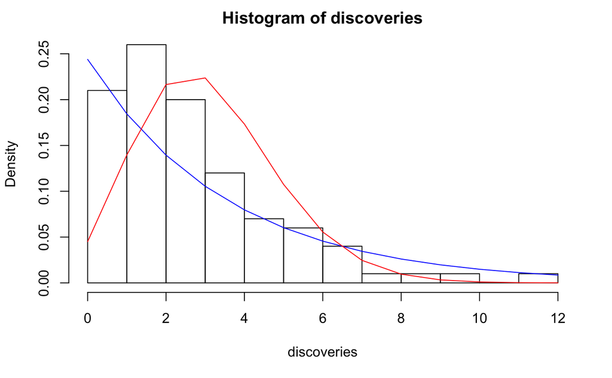

```r
lines(x, dpois(x, lambda, log = FALSE), main = 'densite de Poisson', col='red')
```

**5.** La courbe de Henry de la distribution de Poisson convient le mieux.

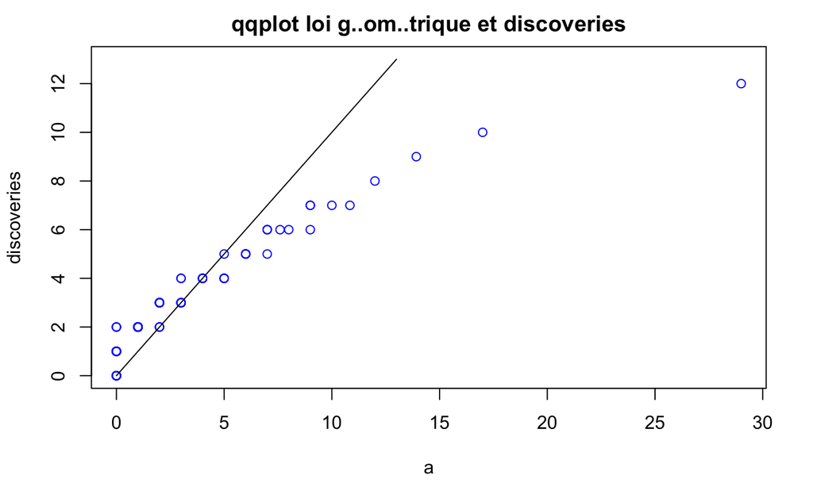

```r
##Utilisation de la fonction qqplot
#preparation des donn<c3><a9>es
a<-rgeom(500, theta)
b<-rpois(500, lambda)
qqplot( a,discoveries, main= 'qqplot loi g<c3><a9>om<c3><a9>trique et discoveries', col='blue', ylim = range(0:13))
lines(0:13,0:13)
```

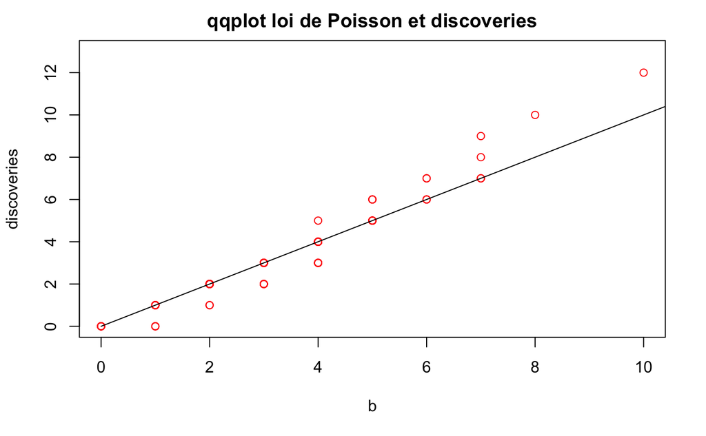

```r
qqplot(b, discoveries, main= 'qqplot loi de Poisson et discoveries', col='red', ylim = range(0:13))
lines(0:13,0:13)
```

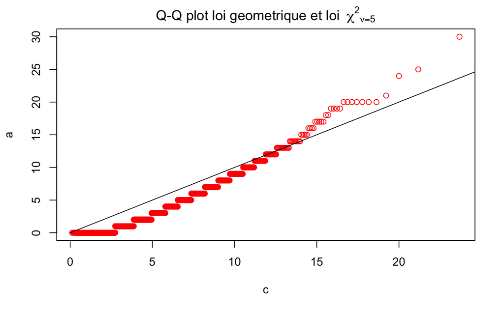

```r
#c<-rchisq(2000, df = 5, ncp=0.05)
c<-qchisq(ppoints(2000), df = 5)
#rappel
a<-rgeom(2000, theta)
b<-rpois(2000, lambda)
## QQPlot pour la loi du Chi^2 compar<c3><a9>e <c3><a0> la ditribution g<c3><a9>om<c3><a9>trique:
qqplot(c, a, main = expression("Q-Q plot loi geometrique et loi"~~ {chi^2}[nu == 5]), col='red')
lines(0:50, 0:50, col='black')
```

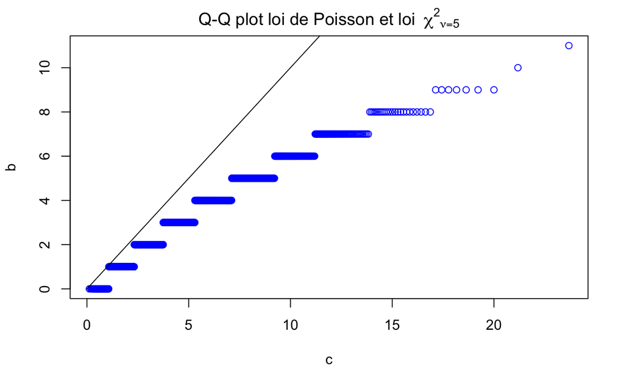

```r
## QQPlot pour la loi du Chi^2 compar<c3><a9>e <c3><a0> la ditribution de Poisson:
qqplot(c,b,main = expression("Q-Q plot loi de Poisson et loi"~~ {chi^2}[nu == 5]), col='blue')
lines(0:25, 0:25, col='black')
```

```r
liste_proba_geom <- list(0.0,0.0,0.0,0.0,0.0,0.0)
for (i in 1:5) {
  liste_proba_geom[i] <- dgeom(i-1, theta)
}
somme_liste <- liste_proba_geom[[1]] + liste_proba_geom[[2]] + liste_proba_geom[[3]] + liste_proba_geom[[4]] + liste_proba_geom[[5]]
liste_proba_geom[6] <- 1.0 - somme_liste
n_j <- list(0.0,0.0,0.0,0.0,0.0,0.0)
for (i in 1:5) {
  n_j[i] <- length(subset(discoveries, discoveries==i-1))
}
n_j[6] <- length(subset(discoveries, discoveries >=5))
print(n_j)
```

```
[[1]]
[1] 9

[[2]]
[1] 12

[[3]]
[1] 26

[[4]]
[1] 20

[[5]]
[1] 12

[[6]]
[1] 21
```

```r
##Calcul de la somme
S <- 0
for (i in 1:6) {
  S <- S + ((n_j[[i]]- 100*liste_proba_geom[[i]])^2)/(100*liste_proba_geom[[i]])
}
print(S)
```

```
[1] 33.46325
```

```r
##Comparaison avec le quantile d'ordre alpha de la loi du Chi 2
q <- qchisq(0.95, df = 5)
q
```

```
[1] 11.0705
```

```r
if (S>q) {
  print('la loi geometrique ne convient pas')
}
```

```
[1] "la loi geometrique ne convient pas"
```

**Loi de Poisson**

```r
#rappel
n_j <- list(0.0,0.0,0.0,0.0,0.0,0.0)
for (i in 1:5) {
  n_j[i] <- length(subset(discoveries, discoveries==i-1))
}
n_j[6] <- length(subset(discoveries, discoveries >=5))
print(n_j)
```

```
[[1]]
[1] 9

[[2]]
[1] 12

[[3]]
[1] 26

[[4]]
[1] 20

[[5]]
[1] 12

[[6]]
[1] 21
```

```r
liste_proba_pois <- list(0.0,0.0,0.0,0.0,0.0,0.0)
for (i in 1:5) {
  liste_proba_pois[i] <- dpois(i-1, lambda)
}
somme_liste_tilde <- liste_proba_pois[[1]] + liste_proba_pois[[2]] + liste_proba_pois[[3]] + liste_proba_pois[[4]] + liste_proba_pois[[5]]
liste_proba_pois[6] <- 1.0 - somme_liste_tilde
##Calcul de la somme
S_tilde <- 0
for (i in 1:6) {
  S_tilde <- S_tilde + ((n_j[[i]]- 100*liste_proba_pois[[i]])^2)/(100*liste_proba_pois[[i]])
}
print(S_tilde)
```

```
[1] 7.563272
```

```r
##Comparaison avec le quantile d'ordre alpha de la loi du Chi 2
q <- qchisq(0.95, df = 5)
q
```

```
[1] 11.0705
```

```r
if (S_tilde<q) {
  print('la loi de Poisson convient')
}
```

```
[1] "la loi de Poisson convient"
```

**Donc la loi de poisson est acceptee**

## Exercice 2 : Analyse de l’incertitude dans le modele de Poisson

**1.** Les $(X_i)$ sont independantes et identiquement distribuees, suivant une loi de Poisson de parametre $\lambda$. Par addivite de la loi de Poisson, la variable aleatoire $(\sum{X_i})$ suit une loi de Poisson de parametre $n\lambda$. On pose $Y=\sum_{i=1}^{n}X_i$ Alors : $\forall s\ge1, P(Y\ge s) = \sum_{k=s}^{+infty} P(Y=k) = \sum_{k=s}^{+infty} \mathrm{e}^{-n\lambda} \frac{(n \lambda)^k }{k!}$ En derivant terme a terme, on obtient : $\frac{\partial P(Y\ge s)}{\partial \lambda}=\sum_{k=s}^{+infty} \mathrm{e}^{-n\lambda} (-\frac{n^{k+1} \lambda^k}{k!} + \frac{n^k \lambda^{k-1}}{(k-1)!} )$ Il s’agit d’une serie entiere ayant pour terme general la difference de deux termes consecutifs. Ainsi, il vient : $\frac{\partial P(Y\ge s)}{\partial \lambda}=\mathrm{e}^{-n\lambda} \frac{n^s \lambda^{s-1}}{(s-1)!} \ge 0$ Donc la fonction est croissante.

**2.** On en dduit un test de de l’hypothse nulle. On utilise le rapport de vraisemblance monotone, pour cela verifions que la fonction de vraisemblance est strictement croisssante $Z(x) = \frac{p_{\theta_2}(x)}{p_{\theta_1}(x)} = \prod_{k=1}^{n} (\frac{\theta_2}{\theta_1})^{x_i} \exp(-n(\theta_2 - \theta_1))$ $\Leftrightarrow Z(x) = \exp(-n(\theta_2 - \theta_1) + log(\frac{\theta_2}{\theta_1}) \sum_{k=1}^{n} x_i) = \exp(-n(\theta_2 - \theta_1) + log(\frac{\theta_2}{\theta_1}) T)$ Or on a pris $\theta_1 < \theta_2$ donc $log(\frac{\theta_2}{\theta_1}) > 0$. Ainsi : la fonction $T \longmapsto \frac{p_{\theta_2}}{p_{\theta_1}}$ est strictement croissante.

T suit une loi de Poisson de parametre $n\lambda$. Sous l’hypothese nulle : $\lambda = 3$.

On a le test suivant : $H_0 : \lambda \le 3$ et $H_1 : \lambda > 3$ avec $\alpha \le 0.05$. On rappelle que le modele est $\theta_0 = \lbrack 0,3 \rbrack$ et $\theta_1 = \rbrack 3, + \infty\lbrack$. Il s’agit de determiner un zone de rejet telle que, sous l’hypothese nulle, la probabilit que X appartienne cette zone $X_1$ soit infrieure ou egale a $5/100$. On s’interesse la statistique $\delta (T) = \mathbb{1} {T>s}$.

On exprime le risque de premiere espece : $R(\theta_0 , \delta) = \alpha = P(\delta(T) = 1) \le 0.05$ $\Leftrightarrow \alpha = P(T > s) \Leftrightarrow \alpha = 1-P(T\le s) \Leftrightarrow P(T\le s) = 1- \alpha$ On retrouve l’expression de la fonction de rpartition de T, dont la reciproque s’exprime comme le quantile $q_1$ associe a la loi $P(3n)$. D’ou : $s = q_1(1-\alpha)$.

```r
alpha = 0.05
s<- qpois(1-alpha, n*3)
print("s = ")
```

```
[1] "s = "
```

```r
qpois(1-alpha, n*3)
```

```
[1] 329
```

**3.** On sait que la somme des dcouvertes de discoveries est de 310 et puisque $310 < 329$, on accepte l’hypothese nulle.

**4.** On considere cette fois la moyenne empirique m de discoveries. Soit $n_0$ le nombre minimum de donnees necessaires pour pouvoir rejeter $H_0$. Pour rejeter le test, il faut : $T(X) > s$, donc : $\sum_{i=1}^{n}X_i > s \Leftrightarrow nm > s$. Finalement : $n_0 = \lfloor \frac{s}{m} \rfloor +1$.

```r
# rappels : m=mean(discoveries)=3.1
print(floor(329/3.1)+1)
```

```
[1] 107
```

Application numrique : il faut au moins $n_0=107$ donnees pour rejeter $H_0$.

**5.** La fonction puissance est donnee par : $\beta(\theta, \delta) = 1- R(\theta, \delta)$ pour $\theta \in \theta_1$. R est ici le risque de premiere espece (rejeter a tort $H_0$). On trace $\beta$ en fonction de $\lambda$.

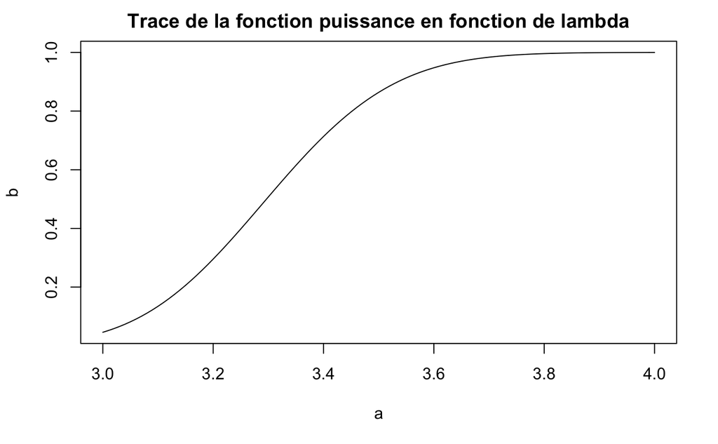

```r
######PLOT DE LA FONCTION PUISSANCE########
j <- 1
n<-100
a <- seq(3,4,0.01)
b <- seq(3,4,0.01)
s<-qpois(0.95, 300)
for (k in a) {
  b[j] <- 1 - ppois(s, n*k)
  j = j+1
}
plot(a,b, type='l', main = 'Trace de la fonction puissance en fonction de lambda')
```

Comme le montre la cellule ci-dessous, il faut 112 donnees pour que $0.9\le \beta(\lambda = 3.5)$

```r
n_donnees <- 1
beta_cible <- 1 - ppois(s, n_donnees*3.5)
while (beta_cible<0.9) {
  n_donnees = n_donnees +1

  beta_cible <- 1 - ppois(qpois(1-0.05, 3*n_donnees), n_donnees*3.5)
}
print(n_donnees)
```

```
[1] 112
```

## Exercice 3 (Analyse bayesienne)

**1.** La distribution du prior conjugue d’une loi de Poisson est une distribution Gamma. Donc $\lambda \hookrightarrow \Gamma(\theta, k)$. Alors $E(\lambda) = k\theta$ et $Var(\lambda) = k\theta^2$. Or d’apres les donnees, il vient : $k=0.25$ et $\theta = 20$.

```r
k_a_estimer <- sum(discoveries)+ 0.25
theta_a_estimer <- 20/(n*20+1)
print(theta_a_estimer)
```

```
[1] 0.009995002
```

```r
print(k_a_estimer)
```

```
[1] 310.25
```